# Assignment 6

## Try to submit as an HTML file

Print your Emory ID below

```python
print('2585210')
```

```
2585210
```

Import the "pandas" and "matplotlib.pyplot" library

```python
# Write your answer here:
import pandas as pd
import matplotlib.pyplot as plt
```

(a) Compute function for each individual (map)

- Import the datset "data/bmi.csv"
  - **Note that the column `Height` is in $cm$, and `Weight` is in $kg$**
- Write a lambda function for $ BMI = \frac{weight (kg)}{height (m)^2} $
- Use `list(map(...))` to calculate $BMI$ for each row of the dataset
- Round the outcome into 2 decimal points
- Store the calculation in a new column in the dataframe called `BMI`
- Display the dataframe

```python
# Write your own code here

bmi = pd.read_csv('data/bmi.csv')
bmi
```

|  | Gender | Height | Weight | Index |
| --- | --- | --- | --- | --- |
| 0 | Male | 174 | 96 | 4 |
| 1 | Male | 189 | 87 | 2 |
| 2 | Female | 185 | 110 | 4 |
| 3 | Female | 195 | 104 | 3 |
| 4 | Male | 149 | 61 | 3 |
| ... | ... | ... | ... | ... |
| 495 | Female | 150 | 153 | 5 |
| 496 | Female | 184 | 121 | 4 |
| 497 | Female | 141 | 136 | 5 |
| 498 | Male | 150 | 95 | 5 |
| 499 | Male | 173 | 131 | 5 |

500 rows × 4 columns

```python
bmi_calculator = lambda Height, Weight: round((Weight/Height),2)

bmi['BMI'] = list(map(bmi_calculator, bmi['Weight'], bmi['Height']))
print(bmi)
```

```
     Gender  Height  Weight  Index   BMI
0      Male     174      96      4  1.81
1      Male     189      87      2  2.17
2    Female     185     110      4  1.68
3    Female     195     104      3  1.88
4      Male     149      61      3  2.44
..      ...     ...     ...    ...   ...
495  Female     150     153      5  0.98
496  Female     184     121      4  1.52
497  Female     141     136      5  1.04
498    Male     150      95      5  1.58
499    Male     173     131      5  1.32

[500 rows x 5 columns]
```

For questions (b)-(d), read "data/wdi_2020.csv"

- This is a dataset containing the proportion  
  of urban population by country in 2020

(b) Convert to upper case

- Create the following function to convert a string to upper case

$\quad$ `fn_upper = lambda x: x.upper()`

- Create a new column, "countryname_upper"  
  that converts "countryname" to upper case.
- Print the original `countryname` and the newly created column, like:  
  "['Afghanistan', 'Africa Eastern and Southern', 'Africa Western and Central', 'Albania', 'Algeria', ......] "

```python
# Write your own code here
wdi_2020 = pd.read_csv('data/wdi_2020.csv')
fn_upper = lambda countryname: countryname.upper()
wdi_2020["Countryname_upper"] = list(map(fn_upper, wdi_2020['countryname']))
wdi_2020
```

|  | year | yearcode | countryname | countrycode | prop_urbanpopulation | Countryname_upper |
| --- | --- | --- | --- | --- | --- | --- |
| 0 | 2020 | YR2020 | Afghanistan | AFG | 26.026000 | AFGHANISTAN |
| 1 | 2020 | YR2020 | Africa Eastern and Southern | AFE | 36.828301 | AFRICA EASTERN AND SOUTHERN |
| 2 | 2020 | YR2020 | Africa Western and Central | AFW | 47.857831 | AFRICA WESTERN AND CENTRAL |
| 3 | 2020 | YR2020 | Albania | ALB | 62.112000 | ALBANIA |
| 4 | 2020 | YR2020 | Algeria | DZA | 73.733000 | ALGERIA |
| ... | ... | ... | ... | ... | ... | ... |
| 261 | 2020 | YR2020 | West Bank and Gaza | PSE | 76.719000 | WEST BANK AND GAZA |
| 262 | 2020 | YR2020 | World | WLD | 56.063764 | WORLD |
| 263 | 2020 | YR2020 | Yemen, Rep. | YEM | 37.908000 | YEMEN, REP. |
| 264 | 2020 | YR2020 | Zambia | ZMB | 44.629000 | ZAMBIA |
| 265 | 2020 | YR2020 | Zimbabwe | ZWE | 32.242000 | ZIMBABWE |

266 rows × 6 columns

(c) Extract sorted elements from a dataset

- Sort by "prop_urbanpopulation" in ascending order
- Subset the 5 countries with the lowest urban population

```python
# Write your code here
wdi_ordered = wdi_2020.sort_values(by = "prop_urbanpopulation", ascending = True)
print(wdi_ordered)
display(wdi_ordered.iloc[0:5,:])
```

```
     year yearcode                countryname countrycode  \
191  2020   YR2020           Papua New Guinea         PNG
34   2020   YR2020                    Burundi         BDI
141  2020   YR2020              Liechtenstein         LIE
177  2020   YR2020                      Niger         NER
149  2020   YR2020                     Malawi         MWI
..    ...      ...                        ...         ...
213  2020   YR2020  Sint Maarten (Dutch part)         SXM
24   2020   YR2020                    Bermuda         BMU
127  2020   YR2020                     Kosovo         XKX
183  2020   YR2020             Not classified         INX
227  2020   YR2020   St. Martin (French part)         MAF

     prop_urbanpopulation          Countryname_upper
191                13.345           PAPUA NEW GUINEA
34                 13.708                    BURUNDI
141                14.416              LIECHTENSTEIN
177                16.626                      NIGER
149                17.427                     MALAWI
..                    ...                        ...
213               100.000  SINT MAARTEN (DUTCH PART)
24                100.000                    BERMUDA
127                   NaN                     KOSOVO
183                   NaN             NOT CLASSIFIED
227                   NaN   ST. MARTIN (FRENCH PART)

[266 rows x 6 columns]
```

|  | year | yearcode | countryname | countrycode | prop_urbanpopulation | Countryname_upper |
| --- | --- | --- | --- | --- | --- | --- |
| 191 | 2020 | YR2020 | Papua New Guinea | PNG | 13.345 | PAPUA NEW GUINEA |
| 34 | 2020 | YR2020 | Burundi | BDI | 13.708 | BURUNDI |
| 141 | 2020 | YR2020 | Liechtenstein | LIE | 14.416 | LIECHTENSTEIN |
| 177 | 2020 | YR2020 | Niger | NER | 16.626 | NIGER |
| 149 | 2020 | YR2020 | Malawi | MWI | 17.427 | MALAWI |

(d) Subset elements with query

- Compute the 25 quantile value of "prop_urbanpopulation"
- Use ".query()" to subset countries with  
  "prop_urbanpopulation" higher the 25 quantile

**hint: Import `numpy` and use `np.nanpercentile`**

```python
# Write your own code here
#find the 25th percentile
import numpy as np
percentile_25 = np.nanpercentile(wdi_2020['prop_urbanpopulation'], 25)
print(percentile_25)
print(type(percentile_25))
subset_25th = wdi_2020.query('prop_urbanpopulation> @percentile_25' ) #or just 42.492392115
print(subset_25th)
```

```
42.492392115
<class 'numpy.float64'>
     year yearcode                 countryname countrycode  \
2    2020   YR2020  Africa Western and Central         AFW
3    2020   YR2020                     Albania         ALB
4    2020   YR2020                     Algeria         DZA
5    2020   YR2020              American Samoa         ASM
6    2020   YR2020                     Andorra         AND
..    ...      ...                         ...         ...
258  2020   YR2020               Venezuela, RB         VEN
260  2020   YR2020       Virgin Islands (U.S.)         VIR
261  2020   YR2020          West Bank and Gaza         PSE
262  2020   YR2020                       World         WLD
264  2020   YR2020                      Zambia         ZMB

     prop_urbanpopulation           Countryname_upper
2               47.857831  AFRICA WESTERN AND CENTRAL
3               62.112000                     ALBANIA
4               73.733000                     ALGERIA
5               87.153000              AMERICAN SAMOA
6               87.916000                     ANDORRA
..                    ...                         ...
258             88.279000               VENEZUELA, RB
260             95.939000       VIRGIN ISLANDS (U.S.)
261             76.719000          WEST BANK AND GAZA
262             56.063764                       WORLD
264             44.629000                      ZAMBIA

[197 rows x 6 columns]
```

(e) Plot by category

- Read "data/wdi_urban.csv"  
  This contains data from 1980 and 2020
- Create a list with the unique values of "year"
- Create a plot with a ...
  - Histogram of "prop_urbanpopulation"  
    for each year
  - Set the histogram option `alpha = 0.5` for transparency
  - All the histograms should be overlapping
  - Create a legend with the list of years
  - Label the axes and the title

What do we learn from the graph?

HINT: See the example at the end of Lecture 10

```
[1980 2020]
```

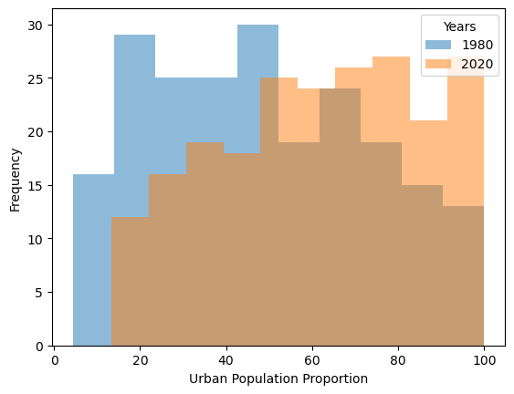

```python
# Write your own code here
#writing list
wdi_urban = pd.read_csv('data/wdi_urban.csv')
#unique years
wdi_years = pd.unique(wdi_urban['year'])
print(wdi_years)
for years in wdi_years:
    df = wdi_urban.query("year == @years")
    plt.hist(df["prop_urbanpopulation"], alpha = .5)

plt.ylabel("Frequency")
plt.xlabel("Urban Population Proportion")
plt.legend(labels = wdi_years,
           title  = "Years")
plt.show()
```

## The graph shows the change in tendency of urban population proportion in 1980 compared to 2020. The data from 2020 shows that the more recent study shows a left skewed, on average higher populaiton proportion compared to the right skewed 1980 data.